# Principal Component Analysis

```r
library(tidyverse)
library(factoextra)
library(ISLR2)
```

## Example 1: Cereal Data

Please download the CerealData.xlsx from Canvas.

```r
dt <- data.table::fread("Data/CerealData.csv")
dt
```

| name | mfr | type | calories | protein | fat | sodium | fiber | carbo | sugars | potass | vitamins | shelf | weight | cups | rating |
| --- | --- | --- | --- | --- | --- | --- | --- | --- | --- | --- | --- | --- | --- | --- | --- |
| 100%_Bran | N | C | 70 | 4 | 1 | 130 | 10.0 | 5.0 | 6 | 280 | 25 | 3 | 1.00 | 0.33 | 68.40297 |
| 100%_Natural_Bran | Q | C | 120 | 3 | 5 | 15 | 2.0 | 8.0 | 8 | 135 | 0 | 3 | 1.00 | 1.00 | 33.98368 |
| All-Bran | K | C | 70 | 4 | 1 | 260 | 9.0 | 7.0 | 5 | 320 | 25 | 3 | 1.00 | 0.33 | 59.42550 |
| All-Bran_with_Extra_Fiber | K | C | 50 | 4 | 0 | 140 | 14.0 | 8.0 | 0 | 330 | 25 | 3 | 1.00 | 0.50 | 93.70491 |
| Almond_Delight | R | C | 110 | 2 | 2 | 200 | 1.0 | 14.0 | 8 | NA | 25 | 3 | 1.00 | 0.75 | 34.38484 |
| Apple_Cinnamon_Cheerios | G | C | 110 | 2 | 2 | 180 | 1.5 | 10.5 | 10 | 70 | 25 | 1 | 1.00 | 0.75 | 29.50954 |
| Apple_Jacks | K | C | 110 | 2 | 0 | 125 | 1.0 | 11.0 | 14 | 30 | 25 | 2 | 1.00 | 1.00 | 33.17409 |
| Basic_4 | G | C | 130 | 3 | 2 | 210 | 2.0 | 18.0 | 8 | 100 | 25 | 3 | 1.33 | 0.75 | 37.03856 |
| Bran_Chex | R | C | 90 | 2 | 1 | 200 | 4.0 | 15.0 | 6 | 125 | 25 | 1 | 1.00 | 0.67 | 49.12025 |
| Bran_Flakes | P | C | 90 | 3 | 0 | 210 | 5.0 | 13.0 | 5 | 190 | 25 | 3 | 1.00 | 0.67 | 53.31381 |

[output cut: 67 more lines]

Let us make a smaller dataset by removing the first three columns.

```r
dt <- na.omit(dt[, !1:3])
```

Estimate PCA

```r
pca <- prcomp(dt)
summary(pca)
```

```
Importance of components:
                           PC1     PC2      PC3      PC4     PC5     PC6     PC7     PC8     PC9    PC10   PC11    PC12      PC13
Standard deviation     83.7641 70.9143 22.64375 19.18148 8.42323 2.09167 1.69942 0.77963 0.65783 0.37043 0.1864 0.06302 5.334e-08
Proportion of Variance  0.5395  0.3867  0.03943  0.02829 0.00546 0.00034 0.00022 0.00005 0.00003 0.00001 0.0000 0.00000 0.000e+00
Cumulative Proportion   0.5395  0.9262  0.96560  0.99389 0.99935 0.99968 0.99991 0.99995 0.99999 1.00000 1.0000 1.00000 1.000e+00
```

The first three Principal Components account for 96.5% of the total variation in 13 variables.

Check the loadings of the principal components

```r
pca$rotation
```

```
                   PC1           PC2           PC3           PC4          PC5          PC6          PC7           PC8          PC9
calories  0.0779841812  0.0093115874 -0.6292057595 -0.6010214629  0.454958508  0.118847832 -0.093856553 -0.0261913392  0.009026694
protein  -0.0007567806 -0.0088010282 -0.0010261160  0.0031999095  0.056175970  0.112745031 -0.258102746  0.6550374420 -0.202405738
fat      -0.0001017834 -0.0026991522 -0.0161957859 -0.0252622140 -0.016098458 -0.131815708 -0.372584401 -0.1179315189  0.123748917
sodium    0.9802145422 -0.1408957901  0.1359018583 -0.0009680741  0.013948118  0.022793038 -0.004508228  0.0006169858 -0.004070832
fiber    -0.0054127550 -0.0306807512  0.0181910456  0.0204721894  0.013605026  0.262841270 -0.043113852 -0.6587762011  0.226879873
carbo     0.0172462607  0.0167832981 -0.0173699816  0.0259482087  0.349266966 -0.537836535  0.672431925  0.0063000824 -0.025163359
sugars    0.0029888631  0.0002534853 -0.0977049979 -0.1154809105 -0.299066459  0.647923362  0.566975323  0.1034662118 -0.117132697
potass   -0.1349000039 -0.9865619808 -0.0367824989 -0.0421757390 -0.047150529 -0.049998579  0.017958664  0.0153755334  0.001213813
vitamins  0.0942933187 -0.0167288404 -0.6919777623  0.7141179984 -0.037008623  0.015757230 -0.012102232  0.0040246634  0.012422225
shelf    -0.0015414195 -0.0043603994 -0.0124888415  0.0056471836 -0.007876459 -0.059901388 -0.092215386 -0.3276114309 -0.934607778
weight    0.0005120017 -0.0009992138 -0.0038059565 -0.0025464145  0.003022113  0.009051564  0.023612969 -0.0028157008  0.002057204
cups      0.0005101111  0.0015910125 -0.0006943214  0.0009853800  0.002148458 -0.010305369  0.019594350  0.0621864112  0.053596315
rating   -0.0752962922 -0.0717421528  0.3079471212  0.3345338994  0.757708025  0.413020626 -0.018324276  0.0119906554 -0.035609664
                  PC10          PC11          PC12          PC13
calories  0.0645173103  0.0089751249 -0.0038531575 -4.193592e-02
protein  -0.2559221836 -0.0452731364  0.0045083697  6.162939e-01
fat      -0.8414403642 -0.0624379207  0.0086033564 -3.184690e-01
sodium   -0.0009169016  0.0002430800 -0.0002327992 -1.026023e-02
fiber    -0.1444774893  0.0210721277 -0.0008106614  6.483602e-01
carbo    -0.3001489644 -0.0418728692 -0.0141471041  2.056936e-01
sugars   -0.3196644966 -0.0281308522 -0.0192731850 -1.364878e-01
potass    0.0063392233  0.0004702207 -0.0009510479 -6.400483e-03
vitamins  0.0005387655 -0.0015435707 -0.0007897848 -9.642514e-03
shelf    -0.0460059018  0.0677694364  0.0103280533 -5.145194e-09
weight    0.0059901667 -0.0929190484  0.9953125849 -9.522241e-08
cups     -0.0803854589  0.9888104372  0.0924845014  2.127112e-08
rating   -0.0227016753  0.0026814544 -0.0031274237 -1.882863e-01
```

The first principal component is dominated by sodium content (positive loading) and the second component is dominated by potassium (negative loading in this case). The sodium and potassium contents are measured in milligrams whereas other quantities are measured in grams. This scale difference is causing this high loadings and needs to be fixed. prcomp() by default centers but we need to specify scale=TRUE to standardize the variables.

```r
pca <- prcomp(dt, scale = TRUE)
summary(pca)
```

```
Importance of components:
                          PC1    PC2    PC3     PC4    PC5     PC6     PC7     PC8     PC9    PC10    PC11    PC12      PC13
Standard deviation     1.9062 1.7743 1.3818 1.00969 0.9947 0.84974 0.81946 0.64515 0.56192 0.30301 0.25194 0.13897 1.499e-08
Proportion of Variance 0.2795 0.2422 0.1469 0.07842 0.0761 0.05554 0.05166 0.03202 0.02429 0.00706 0.00488 0.00149 0.000e+00
Cumulative Proportion  0.2795 0.5217 0.6685 0.74696 0.8231 0.87861 0.93026 0.96228 0.98657 0.99363 0.99851 1.00000 1.000e+00
```

Now we find that 8 principal components are needed to explain 96% of the variability.

Check the new loadings

```r
pca$rotation
```

```
                 PC1        PC2          PC3         PC4         PC5         PC6         PC7          PC8         PC9        PC10
calories  0.29954236  0.3931479 -0.114857453  0.20435870  0.20389885 -0.25590627  0.02559550 -0.002477488 -0.02990943  0.49953153
protein  -0.30735632  0.1653233 -0.277281953  0.30074318  0.31974897  0.12075193 -0.28270494 -0.426631915 -0.53471801 -0.02156642
fat       0.03991542  0.3457243  0.204890102  0.18683311  0.58689327  0.34796727  0.05115470  0.063050445  0.45968763 -0.14508724
sodium    0.18339651  0.1372205 -0.389431009  0.12033726 -0.33836424  0.66437216  0.28370316  0.176720469 -0.21510290 -0.00109092
fiber    -0.45349036  0.1798119 -0.069766079  0.03917361 -0.25511906  0.06424358 -0.11232541  0.216215570  0.24433313  0.29510679
carbo     0.19244902 -0.1494483 -0.562452458  0.08783547  0.18274252 -0.32639279  0.26046798  0.167436379  0.11680691  0.24055692
sugars    0.22806849  0.3514345  0.355405174 -0.02270716 -0.31487243 -0.15208230 -0.22798517 -0.063088121 -0.22538436  0.25165896
potass   -0.40196429  0.3005442 -0.067620183  0.09087843 -0.14836048  0.02515384 -0.14880826  0.262222466  0.16651285  0.17722073
vitamins  0.11598020  0.1729092 -0.387858660 -0.60411064 -0.04928672  0.12948578 -0.29427617 -0.457040884  0.34615102  0.05229538
shelf    -0.17126336  0.2650503  0.001531036 -0.63887859  0.32910135 -0.05204414  0.17483438  0.414145832 -0.41619893 -0.04610229
weight    0.05029930  0.4503085 -0.247138314  0.15342874 -0.22128334 -0.39877368 -0.01392058  0.075247652  0.06507258 -0.69159851
cups      0.29463553 -0.2122479 -0.139999705  0.04748909  0.12081645  0.09946094 -0.74856682  0.498958957 -0.04952533 -0.07705936
rating   -0.43837841 -0.2515389 -0.181842433  0.03831622  0.05758420 -0.18614524 -0.06344456  0.014944982  0.06327447  0.01223508
                 PC11          PC12          PC13
calories -0.213580948 -4.921985e-01 -2.339398e-01
protein   0.032302627  9.969927e-02  1.863851e-01
fat      -0.066832137  2.914159e-01 -9.013898e-02
sodium   -0.087460805  5.371283e-02 -2.387372e-01
fiber    -0.530700425  5.917321e-02  4.417036e-01
carbo     0.178979001  4.759935e-01  2.250341e-01
sugars   -0.003250769  6.142503e-01 -1.672565e-01
potass    0.729209878 -1.207196e-01 -1.275321e-01
vitamins  0.019464859 -4.477121e-05 -6.043328e-02
shelf    -0.059398709  1.654411e-02 -1.203515e-09
weight   -0.112920514 -3.062288e-02 -4.106761e-09
cups     -0.055325530 -3.213026e-02  1.409513e-09
rating   -0.275809192  1.892103e-01 -7.428180e-01
```

By looking at the loadings, we see that the first principal component measures the balance between calories and cups (large positive loadings) vs rating, fiber, protein and potassium (large negative weights). High scores on PC 1 imply cereal is high in calories but low in fiber, protein and potassium. Not s surprise that this type of cereal has low rating Second principal component is most affected by weight.

Create a bi-plot

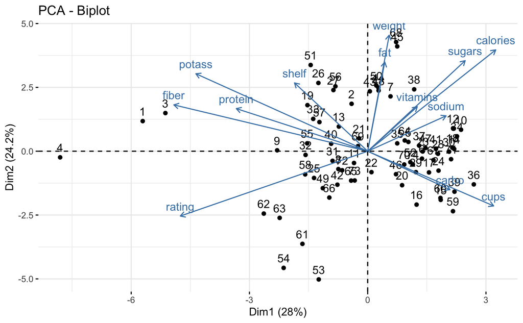

Graph of Variables - Positively correlated variables point to the same side of the plot. Negatively correlated variables point to the opposite sides of the graph.

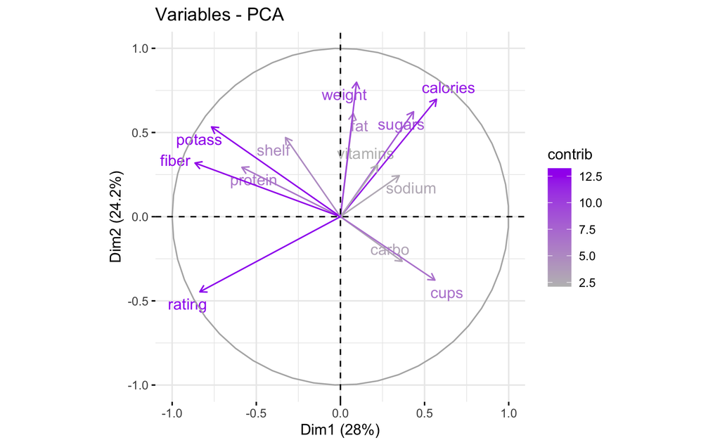

```r
fviz_pca_var(pca,
             col.var = "contrib", # color by contributions to the PC
             gradient.cols = c("gray", "purple"),
             repel=TRUE # avoid text overlapping
             )
```

Scree Plot

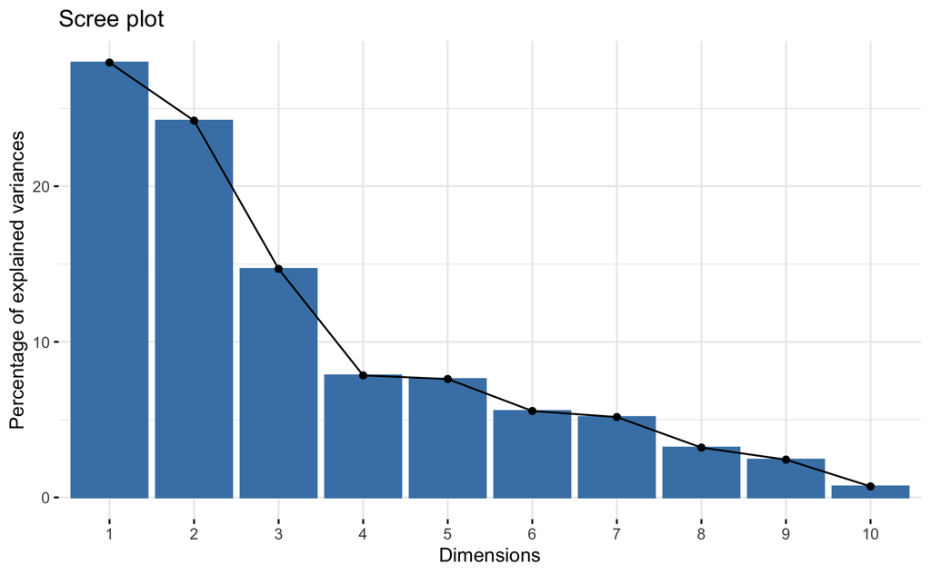

```r
fviz_screeplot(pca)
```

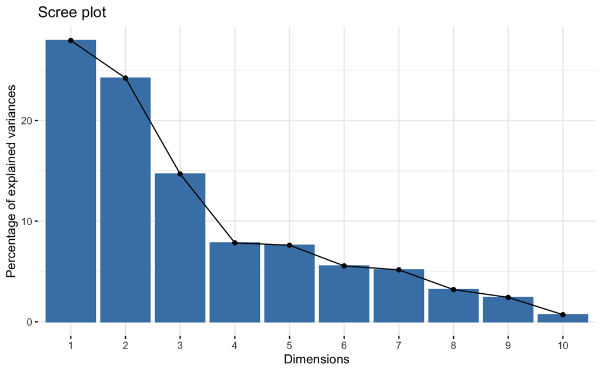

```r
fviz_eig(pca)
```

## Example 2

We will use the USArrests data from the ISLR2 textbook library to perform PCA Load the data and check the first few rows

|  | Murder | Assault | UrbanPop | Rape |
| --- | --- | --- | --- | --- |
| Alabama | 13.2 | 236 | 58 | 21.2 |
| Alaska | 10.0 | 263 | 48 | 44.5 |
| Arizona | 8.1 | 294 | 80 | 31.0 |
| Arkansas | 8.8 | 190 | 50 | 19.5 |
| California | 9.0 | 276 | 91 | 40.6 |
| Colorado | 7.9 | 204 | 78 | 38.7 |
| Connecticut | 3.3 | 110 | 77 | 11.1 |
| Delaware | 5.9 | 238 | 72 | 15.8 |
| Florida | 15.4 | 335 | 80 | 31.9 |
| Georgia | 17.4 | 211 | 60 | 25.8 |

[output cut: 40 more lines]

The data contains information on arrests per 100,000 residents for assault, murder and rape in each state in the US.

```r
summary(pca)
```

```
Importance of components:
                          PC1    PC2     PC3     PC4
Standard deviation     1.5749 0.9949 0.59713 0.41645
Proportion of Variance 0.6201 0.2474 0.08914 0.04336
Cumulative Proportion  0.6201 0.8675 0.95664 1.00000
```

Explore the loadings

```r
pca$rotation
```

```
                PC1        PC2        PC3         PC4
Murder   -0.5358995  0.4181809 -0.3412327  0.64922780
Assault  -0.5831836  0.1879856 -0.2681484 -0.74340748
UrbanPop -0.2781909 -0.8728062 -0.3780158  0.13387773
Rape     -0.5434321 -0.1673186  0.8177779  0.08902432
```

Variable Plot

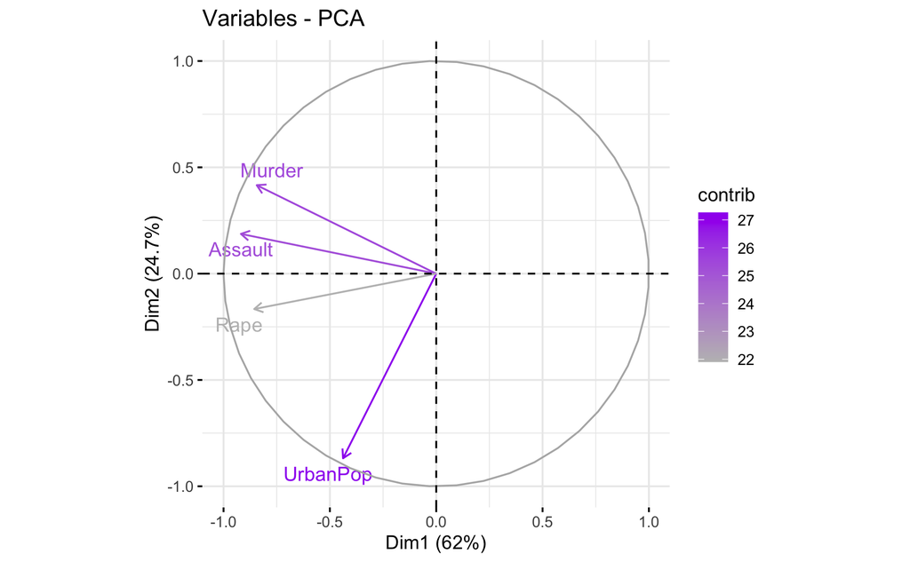

Create a biplot in the PC1-PC2 coordinate systems

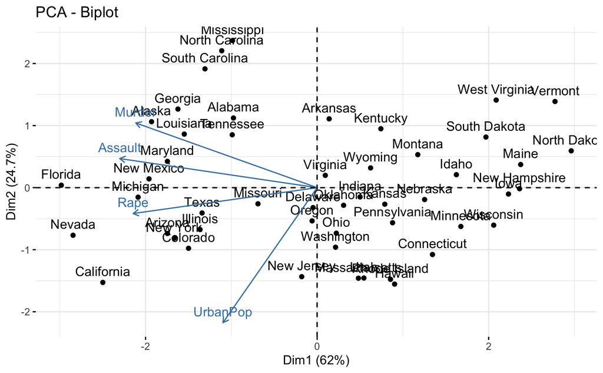

Scree Plot

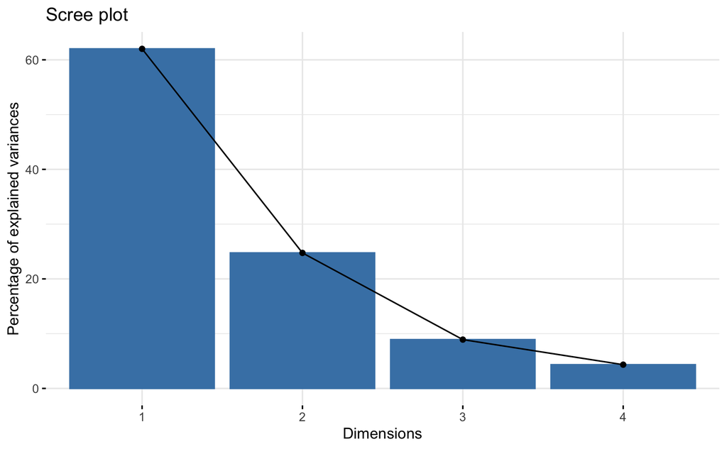